# Democratic Values Project

Anna Valiullina

2026-09-23

```r
library(foreign)
library(dplyr)
library(stringr)
library(tidyr)
```

In this section, I open the LITS data for 2016 and prepare it for the analytical section. As the subject of the study is the countries that were part of the socialist bloc, I needed to exclude observations for certain countries from the dataset.

```r
df <- read.spss("/Users/annavaliullina/Desktop/democarcy research/LITS_2016_III.sav",
                to.data.frame = TRUE,
                reencode = "utf-8")
```

```
## re-encoding from utf-8
```

```r
df_filtered <- df %>%
  mutate(country = str_remove_all(country, '["]') %>% str_trim()) %>%
  mutate(country = case_when(
    country == "Azerbaij" ~ "Azerbaijan",
    country == "Bosnia a" ~ "Bosnia and Herzegovina",
    country == "Czech Re" ~ "Czech Republic",
    country == "FYR Mace" ~ "FYR Macedonia",
    country == "Kazakhst" ~ "Kazakhstan",
    country == "Kyrgyz R" ~ "Kyrgyz Republic",
    country == "Lithuani" ~ "Lithuania",
    country == "Monteneg" ~ "Montenegro",
    country == "Slovak R" ~ "Slovak Republic",
    country == "Tajikist" ~ "Tajikistan",
    country == "Uzbekist" ~ "Uzbekistan",
    TRUE ~ country
  )) %>%
  filter(!country %in% c("Cyprus", "Greece", "Italy", "Germany"))
```

My task was to carry out a factor analysis of the variables relating to democratic values.To begin with, I needed to remove any missing responses from the main variables.

```r
vars <- c("q414a", "q414b", "q414c", "q414d", "q414e", "q414f", "q414g", "q414h")
for (var in vars) {
  clean_var <- paste0(var, "_clean")
  df_filtered[[clean_var]] <- ifelse(df_filtered[[var]] %in% 1:5, df_filtered[[var]], NA)
}
head(df_filtered[c(vars, paste0(vars, "_clean"))])
```

```
##   q414a q414b q414c q414d q414e q414f q414g q414h q414a_clean q414b_clean
## 1     2     3     2     3     1     2     3     4           2           3
## 2     2     2     2     2     2     2     2     2           2           2
## 3     3     2     3     2     3     2     3     2           3           2
## 4     4     3     4     3     4     3     4     3           4           3
## 5     3     2     3     2     3     2     3     2           3           2
## 6     2     2     2     2     2     2     2     2           2           2
##   q414c_clean q414d_clean q414e_clean q414f_clean q414g_clean q414h_clean
## 1           2           3           1           2           3           4
## 2           2           2           2           2           2           2
## 3           3           2           3           2           3           2
## 4           4           3           4           3           4           3
## 5           3           2           3           2           3           2
## 6           2           2           2           2           2           2
```

Once the data had been prepared, I was able to proceed with the factor analysis. As a first step, I carried out an exploratory factor analysis in order to examine the structure of the data and assess the suitability of conducting a factor analysis.

```r
fa_data <- df_filtered %>%
  select(
    q414a_clean,
    q414b_clean,
    q414c_clean,
    q414d_clean,
    q414e_clean,
    q414f_clean,
    q414g_clean,
    q414h_clean
  ) %>%
  drop_na()

corr <- cor(fa_data, method = "spearman")
print(round(corr, 2))
```

```
##             q414a_clean q414b_clean q414c_clean q414d_clean q414e_clean
## q414a_clean        1.00        0.74        0.69        0.69        0.62
## q414b_clean        0.74        1.00        0.72        0.79        0.64
## q414c_clean        0.69        0.72        1.00        0.70        0.72
## q414d_clean        0.69        0.79        0.70        1.00        0.63
## q414e_clean        0.62        0.64        0.72        0.63        1.00
## q414f_clean        0.56        0.57        0.64        0.55        0.71
## q414g_clean        0.68        0.75        0.67        0.75        0.65
## q414h_clean        0.62        0.68        0.68        0.70        0.66
##             q414f_clean q414g_clean q414h_clean
## q414a_clean        0.56        0.68        0.62
## q414b_clean        0.57        0.75        0.68
## q414c_clean        0.64        0.67        0.68
## q414d_clean        0.55        0.75        0.70
## q414e_clean        0.71        0.65        0.66
## q414f_clean        1.00        0.61        0.61
## q414g_clean        0.61        1.00        0.73
## q414h_clean        0.61        0.73        1.00
```

An analysis of Spearman’s rank correlation matrix revealed the existence of moderate and strong positive correlations between all indicators of democratic values

```r
library(psych)
KMO(fa_data)
```

```
## Kaiser-Meyer-Olkin factor adequacy
## Call: KMO(r = fa_data)
## Overall MSA =  0.94
## MSA for each item =
## q414a_clean q414b_clean q414c_clean q414d_clean q414e_clean q414f_clean
##        0.96        0.92        0.95        0.93        0.93        0.93
## q414g_clean q414h_clean
##        0.94        0.96
```

To assess the suitability of the data for factor analysis, the Kaiser–Meyer–Olkin (KMO) test was performed. The Overall MSA was 0.94, which, in accordance with generally accepted criteria, is interpreted as an ‘marvelous’ value (> 0.90). The individual MSA values for each item (q414a_clean – q414h_clean) ranged from 0.92 to 0.96, which significantly exceeds the minimum acceptable threshold (0.50).

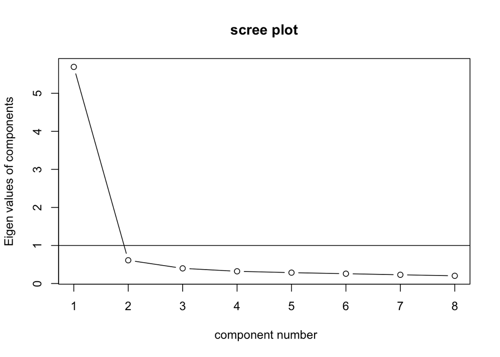

```r
VSS.scree(corr)
```

Although Kaiser’s formal criterion (eigenvalue > 1) indicates a single dominant component, the rocky scree plot and content validity made it possible to identify two theoretically grounded factors.

```r
efa1 <- fa(r = corr, nfactors = 2, fm = "pa", rotate = "varimax")
efa1
```

```
## Factor Analysis using method =  pa
## Call: fa(r = corr, nfactors = 2, rotate = "varimax", fm = "pa")
## Standardized loadings (pattern matrix) based upon correlation matrix
##              PA1  PA2   h2   u2 com
## q414a_clean 0.67 0.45 0.65 0.35 1.7
## q414b_clean 0.81 0.40 0.80 0.20 1.5
## q414c_clean 0.59 0.60 0.71 0.29 2.0
## q414d_clean 0.80 0.38 0.78 0.22 1.4
## q414e_clean 0.41 0.77 0.77 0.23 1.5
## q414f_clean 0.35 0.73 0.66 0.34 1.4
## q414g_clean 0.71 0.47 0.73 0.27 1.7
## q414h_clean 0.61 0.54 0.66 0.34 2.0
##
##                        PA1  PA2
## SS loadings           3.26 2.49
## Proportion Var        0.41 0.31
## Cumulative Var        0.41 0.72
## Proportion Explained  0.57 0.43
## Cumulative Proportion 0.57 1.00
##
## Mean item complexity =  1.7
## Test of the hypothesis that 2 factors are sufficient.
##
## df null model =  28  with the objective function =  6.48
## df of  the model are 13  and the objective function was  0.07
##
## The root mean square of the residuals (RMSR) is  0.01
## The df corrected root mean square of the residuals is  0.02
##
## Fit based upon off diagonal values = 1
## Measures of factor score adequacy
##                                                    PA1  PA2
## Correlation of (regression) scores with factors   0.89 0.85
## Multiple R square of scores with factors          0.80 0.72
## Minimum correlation of possible factor scores     0.60 0.45
```

```r
print(efa1$loadings, cutoff=0.3)
```

```
##
## Loadings:
##             PA1   PA2
## q414a_clean 0.670 0.447
## q414b_clean 0.805 0.396
## q414c_clean 0.594 0.597
## q414d_clean 0.796 0.378
## q414e_clean 0.412 0.773
## q414f_clean 0.352 0.729
## q414g_clean 0.712 0.470
## q414h_clean 0.610 0.538
##
##                  PA1   PA2
## SS loadings    3.256 2.494
## Proportion Var 0.407 0.312
## Cumulative Var 0.407 0.719
```

Based on the results of the exploratory factor analysis, the first factor (PA1), which reflects institutional and procedural aspects, comprises the variables ‘Law and Order’ (loadings 0.81), ‘Peace and stability’ (0.80), ‘An equitable judicial system’ (0.71) and ‘Free and fair elections’ (0.67). The second factor (PA2), relating to civil liberties, comprises the variables ‘Independent press’ (loadings 0.77) and ‘Strong opposition’ (0.73). At the same time, the variables ‘freedom of speech’ (0.59 and 0.60) and ‘equal rights for women’ (0.61 and 0.54) demonstrate pronounced cross-loadings, being distributed between both factors. After that, I can move on to the section on confirmatory factor analysis.

```r
library(lavaan)
```

```r
library(semPlot)
cfa_democracy <- 'Inst_Order =~ q414a_clean + q414b_clean + q414d_clean + q414g_clean
  Lib_Freedoms =~ q414e_clean + q414f_clean'
fit_cfa <- cfa(cfa_democracy, data = fa_data, estimator = "ML")
summary(fit_cfa, fit.measures = TRUE, standardized = TRUE)
```

```
## lavaan 0.6.15 ended normally after 27 iterations
##
##   Estimator                                         ML
##   Optimization method                           NLMINB
##   Number of model parameters                        13
##
##   Number of observations                         38560
##
## Model Test User Model:
##
##   Test statistic                              1166.599
##   Degrees of freedom                                 8
##   P-value (Chi-square)                           0.000
##
## Model Test Baseline Model:
##
##   Test statistic                            158280.442
##   Degrees of freedom                                15
##   P-value                                        0.000
##
## User Model versus Baseline Model:
##
##   Comparative Fit Index (CFI)                    0.993
##   Tucker-Lewis Index (TLI)                       0.986
##
## Loglikelihood and Information Criteria:
##
##   Loglikelihood user model (H0)            -218692.361
##   Loglikelihood unrestricted model (H1)    -218109.061
##
##   Akaike (AIC)                              437410.722
##   Bayesian (BIC)                            437522.001
##   Sample-size adjusted Bayesian (SABIC)     437480.687
##
## Root Mean Square Error of Approximation:
##
##   RMSEA                                          0.061
##   90 Percent confidence interval - lower         0.058
##   90 Percent confidence interval - upper         0.064
##   P-value H_0: RMSEA <= 0.050                    0.000
```

[output cut: 23 more lines]

```
## Covariances:
##                    Estimate  Std.Err  z-value  P(>|z|)   Std.lv  Std.all
##   Inst_Order ~~
##     Lib_Freedoms      0.455    0.004  101.285    0.000    0.823    0.823
##
## Variances:
##                    Estimate  Std.Err  z-value  P(>|z|)   Std.lv  Std.all
##    .q414a_clean       0.343    0.003  123.105    0.000    0.343    0.415
##    .q414b_clean       0.130    0.001   91.893    0.000    0.130    0.196
##    .q414d_clean       0.150    0.001  102.062    0.000    0.150    0.238
##    .q414g_clean       0.196    0.002  108.170    0.000    0.196    0.271
##    .q414e_clean       0.183    0.003   57.676    0.000    0.183    0.224
##    .q414f_clean       0.401    0.004  102.848    0.000    0.401    0.411
##     Inst_Order        0.484    0.006   86.888    0.000    1.000    1.000
##     Lib_Freedoms      0.633    0.006   98.757    0.000    1.000    1.000
```

As the number of degrees of freedom is positive, the model is identified, which makes it empirically testable. SRMR is 0.015 (which is significantly below the strict threshold of 0.05), confirming minimal error in the reproduction of the correlation matrix. The RMSEA (0.061) is slightly above the ideal value (0.05), but falls within the acceptable range (less than 0.08), indicating acceptable approximation quality.

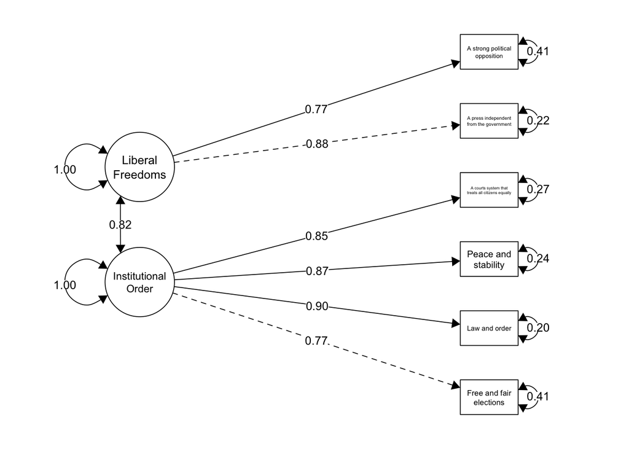

```r
library(semPlot)
semPaths(fit_cfa,
         what = "std",
         rotation = 2,
         nodeLabels = c(

           "Free and fair\nelections",
           "Law and order",
           "Peace and\nstability",
           "A courts system that\ntreats all citizens equally",
           "A press independent\nfrom the government",
           "A strong political\nopposition",


           "Institutional\nOrder",
           "Liberal\nFreedoms"
         ),
         colFactor = 0,
         sizeMan = 10,
         sizeMan2 = 6,
         sizeLat = 12,
         edge.color = "black",
         edge.label.cex = 0.9,
         esize = 1,
         mar = c(3, 8, 3, 8)
)
```

Thus, the factor analysis of democratic values identified two factors that differ substantially in terms of content; these can subsequently be used to analyse differences in the perception of democracy across different countries, including as dependent variables in regression analyses.